# Results

# Graphs générés

La table misAct rassemble des charactéristiques calculées sur chacun des graphes générées.

- nH : nombre de voisins de l’acteur manquant
- mean.cpH : moyenne des corrélations partielles sortantes de l’acteur manquant
- mean.vv : nombre moyen de voisins des voisins de l’acteur manquant
- max.maxDeg : degré maximal parmi les voisins des voisins de l’acteur manquant
- mean.maxDeg : moyenne des degrés maximaux des voisins de voisins de l’acteur manquant
- mean.btw : moyenne des betweenness des voisins de l’acteur manquant
- btwH : betweenness de l’acteur manquant.

```r
misAct=build_misAct(simus, H=15)
misAct[1:5,] %>% kable %>% kable_styling()
```

| nH | mean.cpH | mean.vv | max.maxDeg | mean.maxDeg | mean.btw | btwH |
| --- | --- | --- | --- | --- | --- | --- |
| 7 | -0.3148500 | 1.285714 | 4 | 2.500000 | 0.4420290 | 69 |
| 4 | -0.3311606 | 2.250000 | 3 | 2.333333 | 0.5384615 | 65 |
| 11 | -0.2635695 | 1.181818 | 2 | 2.000000 | 0.4117647 | 85 |
| 7 | -0.2813651 | 1.857143 | 2 | 1.333333 | 0.3586498 | 79 |
| 5 | -0.3182708 | 2.000000 | 4 | 2.333333 | 0.4747475 | 66 |

Les résultats sont résumés en regroupant les graphes par l’influence de leur acteur manquant :

- minor : l’acteur manquant est lié à moins du tiers des noeuds ($nH<5$)
- medium : l’acteur manquant est lié à entre le tiers et la moitié des noeuds ( $5 \leq nH < 7$)
- major : l’acteur manquant est lié à plus de la moitié des noeuds ($nH \geq 7$)

```r
misAct=misAct %>% mutate(influence=unlist(purrr::map(nH, function(x){
    if(x<5) res="minor"
    if(x>=5 & x<7) res="medium"
    if(x>=7) res="major"
    return(res)})))

misAct %>% group_by(influence) %>% summarise(count=n())%>% kable %>% kable_styling()
```

| influence | count |
| --- | --- |
| major | 217 |
| medium | 158 |
| minor | 24 |

# Convergence de VEMtree

Tous les VEMtree ont convergé, mais pas de la même manière. L’algo VEMtree a trois critères d’arrêt :

- W et Omega convergent,
- la borne inférieure converge,
- maxIter a été atteint.

Donc VEMtree peut s’être arrêté du fait de la borne inf indépendemment de la convergence sur les paramètres W et Omega. Dans ce qui suit, on voit que maxIter (qui vaut 200) n’a jamais été atteint, et que lorsque c’est la convergence de J qui permet l’arrêt de l’algorithme, Omega a convergé mais pas W.

```r
# nb de stops par J au lieu des paramètres :
stopJ=do.call(rbind, lapply(simus, function(graine){
  diffW = tail(graine$VEM_1$features$diffW,1)
  diffOm = tail(graine$VEM_1$features$diffOm,1)
  return(diffW>1e-3 || diffOm>1e-3)
}))
nb.stopJ = sum(stopJ)
# nb.stopJ = 145
# est-ce qu'on était loin de eps pour W et Om quand J a stoppé ?
diffOm=do.call(rbind, lapply(simus, function(graineJ){
  diffOm = tail(graineJ$VEM_1$features$diffOm,1)
}))
sum(diffOm[which(stopJ)]<1e-3) # en fait tous les Omega ont convergé
```

```
## [1] 380
```

```r
diffW=do.call(rbind, lapply(simus, function(graineJ){
  diffW = tail(graineJ$VEM_1$features$diffW,1)
}))
# hist(log(diffW[which(stopJ)]), main="log(diffW) quand diffW>eps", xlab="", ylab="",
#      col="#FA7E1E", border=FALSE)
# sum(diffW[which(stopJ)]>0.1) # 79
# weird.conv = which(do.call(rbind, lapply(simus, function(graine){
#   diffW = tail(graine$VEM_1$features$diffW,1)
#   return(diffW > 1e-3)
# })))
# # donc divergence des poids W pour 40% des graines
# data.frame(diffW= diffW, diffOm= diffOm, nH=misAct$nH) %>% as_tibble() %>%
#   group_by(nH) %>% summarise(count=n(), noWconv = sum(diffW>1e-3), prop=round(100*noWconv/count, 1)) %>% kable() %>% kable_styling()
#
# weird.iter=do.call(rbind, lapply(simus[weird.conv], function(graine){
#   graine$VEM_1$finalIter
# })) # longue queue : entre 13 et 135, mean=41.5 sd = 25
# good.iter=do.call(rbind, lapply(simus[-weird.conv], function(graine){
#   graine$VEM_1$finalIter
# })) # entre 12 et 180, mean = 32.5, sd = 18, (31 et 12.5 si on enlève la valeur extrême)
# data.frame(iter = rbind(weird.iter, good.iter),
#            Wconv = as.factor(rep(c(0,1),c(length(weird.iter),length(good.iter))) ) )%>%
#   ggplot(aes(Wconv, iter, color=Wconv))+geom_boxplot()+mytheme.dark("W converged")
```

# Qualité d’inférence

## Réseau et position de l’acteur manquant

La qualité d’inférence est évaluée avec l’AUC, la PPV (TP/(TP+FP)) et le TPR (TP/(TP+FN)) des arêtes incluant l’acteur manquant, notés PPVH et TPRH. Ces valeurs sont calculées pour chaque graphes, et les proportion de valeurs supérieures à 0.8 sont mises en liens avec le nombre de voisins nH de l’acteur manquant.

```r
Qual<-data.frame(auc=do.call(rbind, lapply(simus, function(seed){
  Pg=seed$VEM_1$Pg
  ome=seed$omega
  diag(ome)=0
  auc=round(auc(pred = Pg, label = ome),4)
  return(auc)
})),ppvh=do.call(rbind, lapply(simus, function(seed){
  Pg=seed$VEM_1$Pg ;ome=seed$omega ;diag(ome)=0 ;H=15
  ppvh=accppvtpr(Pg,ome,h=H,seuil=0.5)[5]
  return(ppvh)
})),tprh=do.call(rbind, lapply(simus, function(seed){
  Pg=seed$VEM_1$Pg ;ome=seed$omega ; diag(ome)=0 ; H=15
  ppvh=accppvtpr(Pg,ome,h=H,seuil=0.5)[8]
  return(ppvh)
})), seed = (1:400)[-badseed]) %>% as_tibble() %>% mutate( nH =misAct$nH,
                                               influence=misAct$influence)

Qual %>% group_by(nH) %>% summarise( count=n(),auc.prop80 = round(sum(auc>0.8)*100/count, 1), pvh.prop80 = round(sum(ppvh>0.8)*100/count, 1))%>% kable() %>% kable_styling()
```

| nH | count | auc.prop80 | pvh.prop80 |
| --- | --- | --- | --- |
| 3 | 2 | 0.0 | 0.0 |
| 4 | 22 | 4.5 | 0.0 |
| 5 | 72 | 6.9 | 1.4 |
| 6 | 86 | 11.6 | 4.7 |
| 7 | 96 | 28.1 | 17.7 |
| 8 | 46 | 19.6 | 19.6 |
| 9 | 35 | 25.7 | 34.3 |
| 10 | 23 | 26.1 | 73.9 |
| 11 | 14 | 21.4 | 78.6 |
| 12 | 1 | 0.0 | 100.0 |
| 13 | 2 | 0.0 | NA |

```r
Qual %>% group_by(influence) %>%
  summarise(count=n(), med.auc=round(median(auc), 2),
                              auc.prop80 = round(sum(auc>0.8)*100/count, 1))%>%
  kable() %>% kable_styling()
```

| influence | count | med.auc | auc.prop80 |
| --- | --- | --- | --- |
| major | 217 | 0.64 | 24.9 |
| medium | 158 | 0.45 | 9.5 |
| minor | 24 | 0.46 | 4.2 |

```r
Qual %>% group_by(influence) %>% summarise( count=n(), med.ppvh=round(median(ppvh, na.rm=TRUE),2), med.tprh=round(median(tprh),2), ppvh.prop80 = round(sum(ppvh>0.8, na.rm=TRUE)*100/count, 1),tprh.prop80 = round(sum(tprh>0.8)*100/count, 1))%>%
  kable() %>% kable_styling()
```

| influence | count | med.ppvh | med.tprh | ppvh.prop80 | tprh.prop80 |
| --- | --- | --- | --- | --- | --- |
| major | 217 | 0.67 | 0.57 | 31.3 | 13.4 |
| medium | 158 | 0.29 | 0.33 | 3.2 | 9.5 |
| minor | 24 | 0.14 | 0.25 | 0.0 | 16.7 |

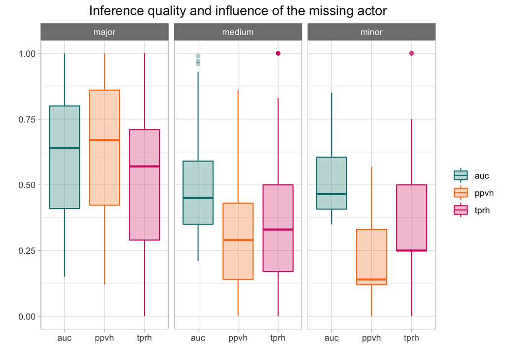

```r
Qual %>% gather(key, value, -nH,  -influence, -seed) %>%
  ggplot(aes(key, value, color=key, fill=key))+geom_boxplot(alpha=0.3)+
  facet_grid(~as.factor(influence))+mytheme.dark("")+
  labs(x="", y="", title="Inference quality and influence of the missing actor")
```

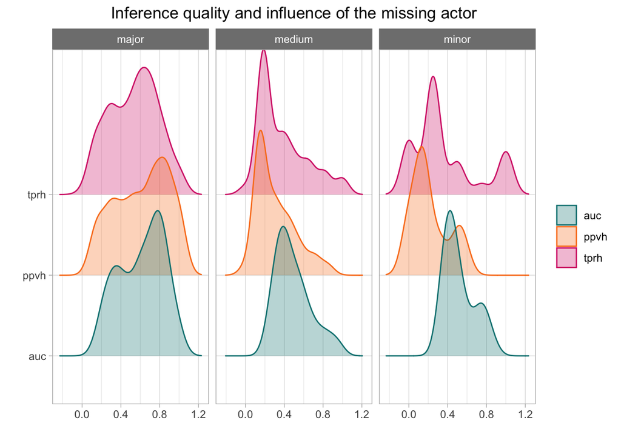

```r
Qual %>% gather(key, value, -nH,  -influence, -seed) %>%
  ggplot(aes(value, key, color=key, fill=key))+geom_density_ridges(alpha=0.3)+
  facet_grid(~as.factor(influence))+mytheme.dark("")+
  labs(x="", y="", title="Inference quality and influence of the missing actor")
```

## Reconstruction de l’acteur manquant

La reconstruction de l’acteur manquant est évaluée par la corrélation entre le vecteur latent gaussien d’origine $Z_H$, et le vecteur des moyennes inférées $M_H$.

```r
cor_ZHMH=do.call(rbind, lapply(simus, function(graine){
  ZH=graine$ZH
  MH = graine$VEM_1$M[,H]
  return(cor(ZH, MH))
}))
datacor=data.frame(corZM=abs(cor_ZHMH), nH=misAct$nH, influence=misAct$influence)
datacor%>%
  group_by(influence) %>% summarize(med.cor=round(median(corZM),2), prop50 = round(100*sum(corZM>0.5)/n(),1)) %>% kable() %>% kable_styling()
```

| influence | med.cor | prop50 |
| --- | --- | --- |
| major | 0.73 | 77.9 |
| medium | 0.46 | 41.1 |
| minor | 0.37 | 33.3 |

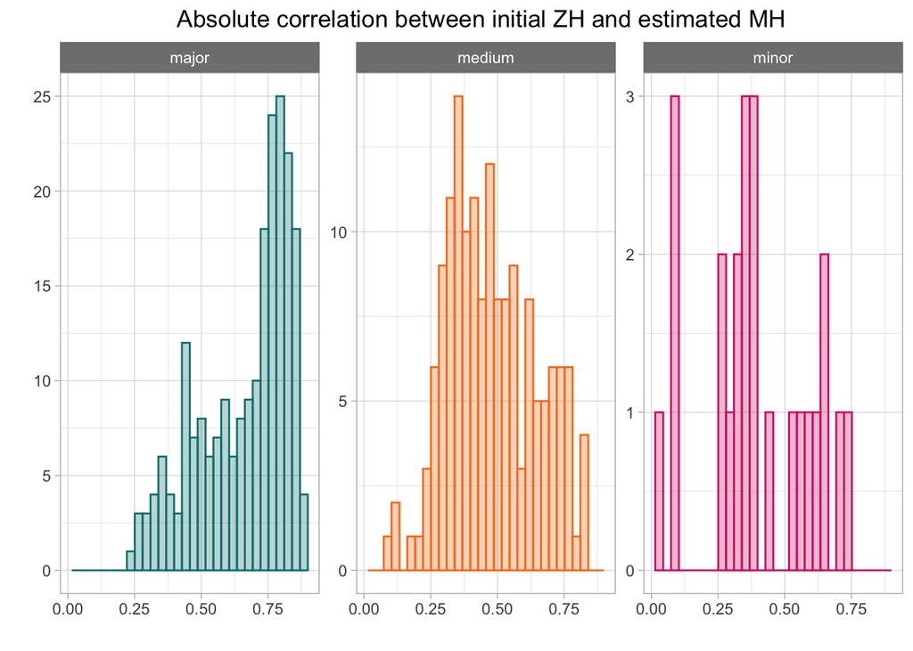

```r
datacor %>% ggplot(aes(corZM, color=influence, fill=influence))+
  geom_histogram(alpha=0.3)+facet_wrap(~influence, scales="free_y")+mytheme.dark("")+
  guides(color=FALSE, fill=FALSE)+labs(x="",y="", title="Absolute correlation between initial ZH and estimated MH")
```

# Bornes inférieures

```r
bornesJ=do.call(rbind, lapply(simus, function(graine){
  tail(graine$VEM_1$lowbound$J,1)
}))
ICL=do.call(rbind, lapply(simus, function(graine){
  J=tail(graine$VEM_1$lowbound$J,1)
  pen_T=-( sum( graine$VEM_1$Pg * log(graine$VEM_1$Wg+(graine$VEM_1$Wg==0)) ) - logSumTree(graine$VEM_1$Wg)$det )
  return(J-pen_T)
}))
```

[output not shown]

```r
datacor=datacor %>% mutate(goodcor=ifelse(corZM>0.5,"cor>0.5","cor<0.5"),
                   borneJ = bornesJ,icl=ICL,
                    nH=misAct$nH)
which(datacor$influence=="major" & datacor$goodcor=="cor<0.5")
```

```
##  [1]  10  31  40  41  43  44  69  80  81  82  92  93  94 103 117 139 152
## [18] 155 172 176 178 186 217 226 236 246 247 252 254 289 292 305 310 312
## [35] 313 320 352 353 358 367 373 375 378 381 383 384 387 392
```

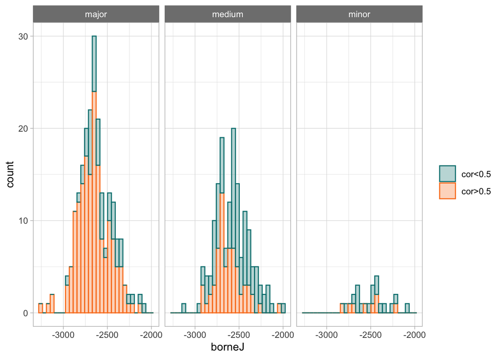

```r
datacor %>%
  ggplot(aes(borneJ, color=goodcor,fill=goodcor))+
  geom_histogram(alpha=0.3)+mytheme.dark("")+facet_wrap(~influence)
```

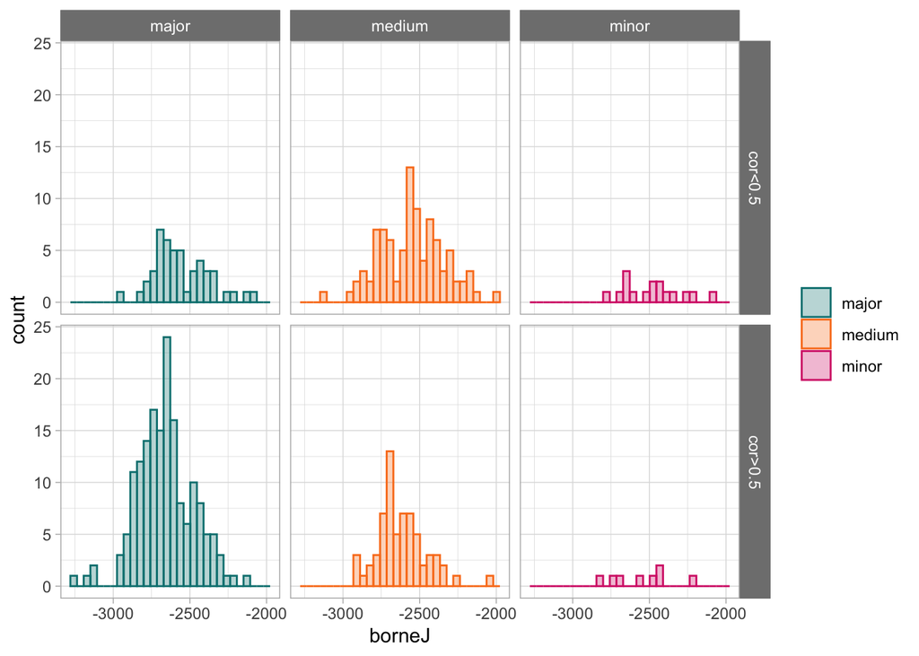

```r
datacor %>%
  ggplot(aes(borneJ, color=influence,fill=influence))+
  geom_histogram(alpha=0.3)+mytheme.dark("")+facet_grid(goodcor~influence)
```

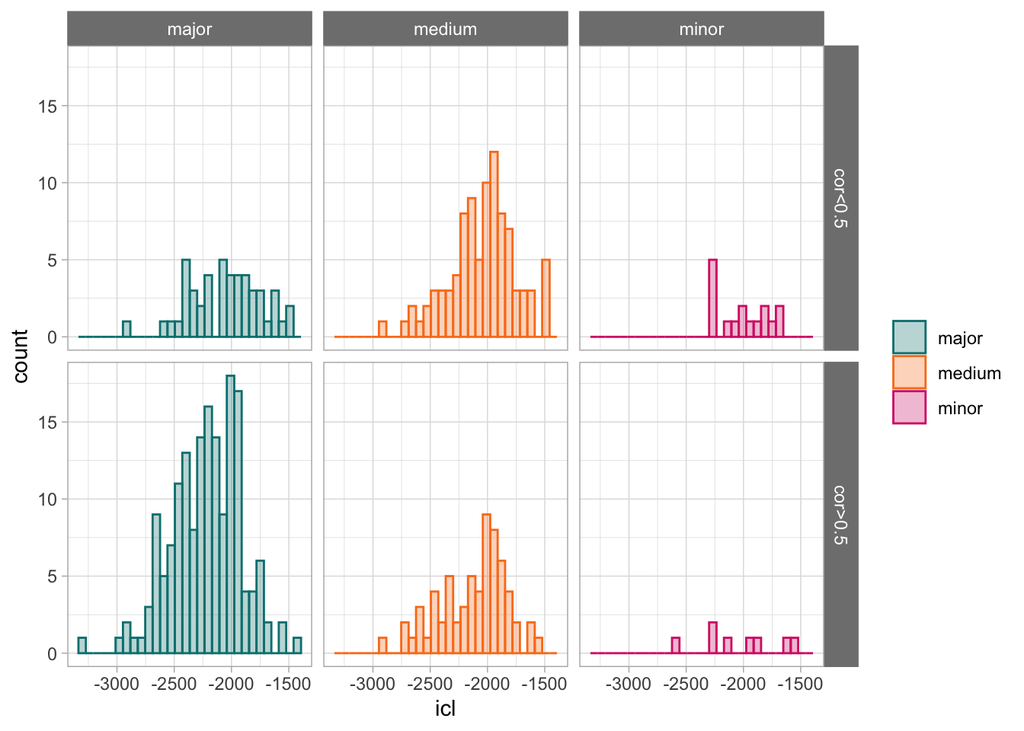

```r
datacor %>%
  ggplot(aes(icl, color=influence,fill=influence))+
  geom_histogram(alpha=0.3)+mytheme.dark("")+facet_grid(goodcor~influence)
```